# Final Project

2024-12-07

## **Project Summary**

**In this project we’re analyzing the John’s Hopkins Covid19 data. I specifically want to look compare a few countries/states that had notoriously strict lockdown policies to countries/states that had notoriously lenient lockdown polices. My goal is to understand how strict vs. lenient policy affected the number of cases and deaths over time. The goal of this project is to simulate how a policy maker might go about making lockdown decisions for future pandemics.**

## **Step 1: Import**

**Import the libraries we need and import the data we’ll use for the analysis**

```r
library(tidyverse)
library(lubridate)
```

```r
url_in <- "https://raw.githubusercontent.com/CSSEGISandData/COVID-19/master/csse_covid_19_data/csse_covid_19_time_series/"
file_names <- c("time_series_covid19_confirmed_US.csv","time_series_covid19_confirmed_global.csv", "time_series_covid19_deaths_US.csv","time_series_covid19_deaths_global.csv")
urls <- str_c(url_in,file_names)
global_cases <- read_csv(urls[2])
global_deaths <- read_csv(urls[4])
US_cases <- read_csv(urls[1])
US_deaths <- read_csv(urls[3])
uid_lookup_url <- "https://raw.githubusercontent.com/CSSEGISandData/COVID-19/master/csse_covid_19_data/UID_ISO_FIPS_LookUp_Table.csv"
uid <- read_csv(uid_lookup_url) %>%
  select(-c(Lat, Long_, Combined_Key, code3, iso2, iso3, Admin2))
```

Description of the dataset from the Github source page: ‘contains daily time series summary tables, including confirmed, deaths and recovered. All data is read in from the daily case report. The time series tables are subject to be updated if inaccuracies are identified in our historical data.’

## **Step 2: Transform/Tidy**

**Here we’ll transform and tidy up data for analysis. Remove unnecessary columns, pivot the time series data, and join the data as needed. The end goal here is to make the data ready for visualization, analysis, and modeling.**

Let’s start with the global data.

```r
global_cases <- global_cases %>%
  pivot_longer(
    cols = -c(`Province/State`, `Country/Region`, Lat, Long),
    names_to = "date",
    values_to = "cases"
  ) %>%
  select(-c(Lat, Long))

global_deaths <- global_deaths %>%
  pivot_longer(
    cols = -c(`Province/State`, `Country/Region`, Lat, Long),
    names_to = "date",
    values_to = "deaths"
  ) %>%
  select(-c(Lat, Long))

global <- global_cases %>%
  full_join(global_deaths) %>%
  rename(
    Country_Region = `Country/Region`,
    Province_State = `Province/State`
  ) %>%
  mutate(date = mdy(date))
global <- global_cases %>%
  full_join(global_deaths) %>%
  rename(
    Country_Region = `Country/Region`,
    Province_State = `Province/State`
  ) %>%
  mutate(date = mdy(date))
global <- global %>%
  unite("Combined_Key",
        c(Province_State, Country_Region),
        sep = ", ",
        na.rm = TRUE,
        remove = FALSE)

global <- global %>%
  left_join(uid, by = c("Province_State","Country_Region")) %>%
  select(-c(UID, FIPS)) %>%
  select(Province_State, Country_Region, date, cases, deaths, Population, Combined_Key)

# aggregate data at the country level
global <- global %>%
  group_by(Country_Region, date) %>%
  summarize(
    cases = sum(cases, na.rm = TRUE),
    deaths = sum(deaths, na.rm = TRUE),
    # aggregate population based on presence of Province_State- we need to do this because there are countries that are broken out by state, and some countries are not. We don't want to sum pop in countries that don't have it broken out by state
    Population = if (all(is.na(Province_State))) {
      max(Population, na.rm = TRUE) # if no Province/State, take max (country-level value)
    } else {
      sum(Population, na.rm = TRUE) # if Province/State exists, sum the population
    }
  ) %>%
  ungroup()
# calculate per-million metrics
global <- global %>%
  mutate(
    deaths_per_mill = deaths * 1000000 / Population,
    cases_per_mill = cases * 1000000 / Population
  )

#lets look at the data high level
global
```

```
## # A tibble: 229,743 × 7
##    Country_Region date       cases deaths Population deaths_per_mill
##    <chr>          <date>     <dbl>  <dbl>      <dbl>           <dbl>
##  1 Afghanistan    2020-01-22     0      0   38928341               0
##  2 Afghanistan    2020-01-23     0      0   38928341               0
##  3 Afghanistan    2020-01-24     0      0   38928341               0
##  4 Afghanistan    2020-01-25     0      0   38928341               0
##  5 Afghanistan    2020-01-26     0      0   38928341               0
##  6 Afghanistan    2020-01-27     0      0   38928341               0
##  7 Afghanistan    2020-01-28     0      0   38928341               0
##  8 Afghanistan    2020-01-29     0      0   38928341               0
##  9 Afghanistan    2020-01-30     0      0   38928341               0
## 10 Afghanistan    2020-01-31     0      0   38928341               0
## # ℹ 229,733 more rows
## # ℹ 1 more variable: cases_per_mill <dbl>
```

```r
summary(global)
```

```
##  Country_Region          date                cases               deaths
##  Length:229743      Min.   :2020-01-22   Min.   :        0   Min.   :      0
##  Class :character   1st Qu.:2020-11-02   1st Qu.:     3831   1st Qu.:     46
##  Mode  :character   Median :2021-08-15   Median :    52933   Median :    786
##                     Mean   :2021-08-15   Mean   :  1379412   Mean   :  19238
##                     3rd Qu.:2022-05-28   3rd Qu.:   499592   3rd Qu.:   7227
##                     Max.   :2023-03-09   Max.   :103802702   Max.   :1123836
##    Population        deaths_per_mill    cases_per_mill
##  Min.   :     -Inf   Min.   :   0.000   Min.   :     0.0
##  1st Qu.:1.403e+06   1st Qu.:   9.551   1st Qu.:   662.8
##  Median :8.655e+06   Median : 130.436   Median :  8502.9
##  Mean   :     -Inf   Mean   : 650.558   Mean   : 64474.2
##  3rd Qu.:2.769e+07   3rd Qu.: 944.563   3rd Qu.: 76155.9
##  Max.   :1.418e+09   Max.   :6658.378   Max.   :695857.2
```

```r
US_cases <- US_cases %>%
  pivot_longer(
    cols = -(UID:Combined_Key),
    names_to = "date",
    values_to = "cases"
  ) %>%
  select(Admin2:cases) %>%
  mutate(date = mdy(date)) %>%
  select(-c(Lat, Long_))
US_deaths <- US_deaths %>%
  pivot_longer(
    cols = -(UID:Population),
    names_to = "date",
    values_to = "deaths"
  ) %>%
  select(Admin2:deaths) %>%
  mutate(date = mdy(date)) %>%
  select(-c(Lat, Long_))
US <- US_cases %>%
  full_join(US_deaths)
```

[output not shown]

```r
US_by_state <- US %>%
  group_by(Province_State, Country_Region, date) %>%
  summarize(
    cases = sum(cases),
    deaths = sum(deaths),
    Population = sum(Population)
  ) %>%
  mutate(
    deaths_per_mill = deaths * 1000000 / Population,
    cases_per_mill = cases * 1000000 / Population
  ) %>%
  select(
    Province_State,
    Country_Region,
    date,
    cases,
    deaths,
    deaths_per_mill,
    cases_per_mill,
    Population
  ) %>%
  ungroup()
#lets look at the data high level
US_by_state
```

```
## # A tibble: 66,294 × 8
##    Province_State Country_Region date       cases deaths deaths_per_mill
##    <chr>          <chr>          <date>     <dbl>  <dbl>           <dbl>
##  1 Alabama        US             2020-01-22     0      0               0
##  2 Alabama        US             2020-01-23     0      0               0
##  3 Alabama        US             2020-01-24     0      0               0
##  4 Alabama        US             2020-01-25     0      0               0
##  5 Alabama        US             2020-01-26     0      0               0
##  6 Alabama        US             2020-01-27     0      0               0
##  7 Alabama        US             2020-01-28     0      0               0
##  8 Alabama        US             2020-01-29     0      0               0
##  9 Alabama        US             2020-01-30     0      0               0
## 10 Alabama        US             2020-01-31     0      0               0
## # ℹ 66,284 more rows
## # ℹ 2 more variables: cases_per_mill <dbl>, Population <dbl>
```

```r
summary(US_by_state)
```

```
##  Province_State     Country_Region          date                cases
##  Length:66294       Length:66294       Min.   :2020-01-22   Min.   :       0
##  Class :character   Class :character   1st Qu.:2020-11-02   1st Qu.:   31115
##  Mode  :character   Mode  :character   Median :2021-08-15   Median :  293146
##                                        Mean   :2021-08-15   Mean   :  811738
##                                        3rd Qu.:2022-05-28   3rd Qu.:  953450
##                                        Max.   :2023-03-09   Max.   :12129699
##
##      deaths       deaths_per_mill  cases_per_mill     Population
##  Min.   :     0   Min.   :   0.0   Min.   :     0   Min.   :       0
##  1st Qu.:   555   1st Qu.: 490.2   1st Qu.: 24584   1st Qu.: 1068778
##  Median :  3849   Median :1665.9   Median :116245   Median : 3660113
##  Mean   : 10768   Mean   :   Inf   Mean   :   Inf   Mean   : 5739226
##  3rd Qu.: 13695   3rd Qu.:2794.0   3rd Qu.:257904   3rd Qu.: 6892503
##  Max.   :101159   Max.   :   Inf   Max.   :   Inf   Max.   :39512223
##                   NA's   :1211     NA's   :109
```

## **Step 3: Data visualization section**

**In this section we’ll visualize a couple of examples of strict vs. lenient countries with regard to covid lockdown policies.**

Let’s first compare at the country level, Sweden and Australia.

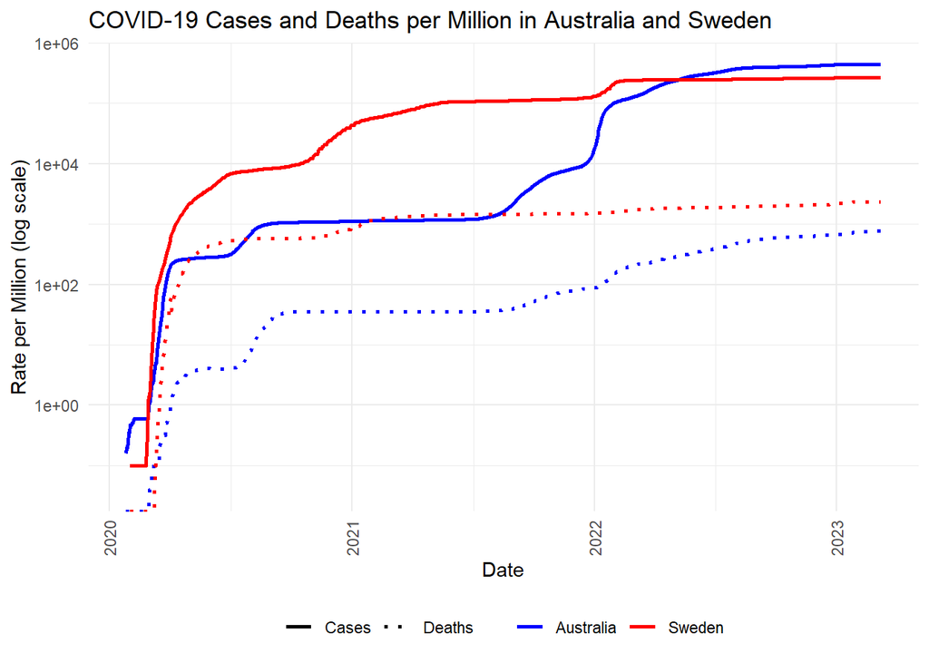

```r
# filter data for Australia and Sweden
global %>%
  filter(Country_Region %in% c("Australia", "Sweden")) %>%
  filter(cases > 0) %>%
  ggplot(aes(x = date)) +
  # Plot Australia cases
  geom_line(
    data = . %>% filter(Country_Region == "Australia"),
    aes(y = cases_per_mill, color = "Australia", linetype = "Cases"),
    size = 1
  ) +
  # plot Australia deaths
  geom_line(
    data = . %>% filter(Country_Region == "Australia"),
    aes(y = deaths_per_mill, color = "Australia", linetype = "Deaths"),
    size = 1
  ) +
  # plot Sweden cases
  geom_line(
    data = . %>% filter(Country_Region == "Sweden"),
    aes(y = cases_per_mill, color = "Sweden", linetype = "Cases"),
    size = 1
  ) +
  # plot Sweden deaths
  geom_line(
    data = . %>% filter(Country_Region == "Sweden"),
    aes(y = deaths_per_mill, color = "Sweden", linetype = "Deaths"),
    size = 1
  ) +
  scale_color_manual(
    values = c("Australia" = "blue", "Sweden" = "red")
  ) +
  scale_linetype_manual(
    values = c("Cases" = "solid", "Deaths" = "dotted")
  ) +
  # customize y axis to use a log scale for better comparison
  scale_y_log10() +
  theme_minimal() +
  theme(
    legend.position = "bottom",
    axis.text.x = element_text(angle = 90, vjust = 0.5, hjust = 1),
    legend.title = element_blank()
  ) +
  labs(
    title = "COVID-19 Cases and Deaths per Million in Australia and Sweden",
    x = "Date",
    y = "Rate per Million (log scale)"
  )
```

Next we’ll compare a couple of states, Hawaii and South Dakota

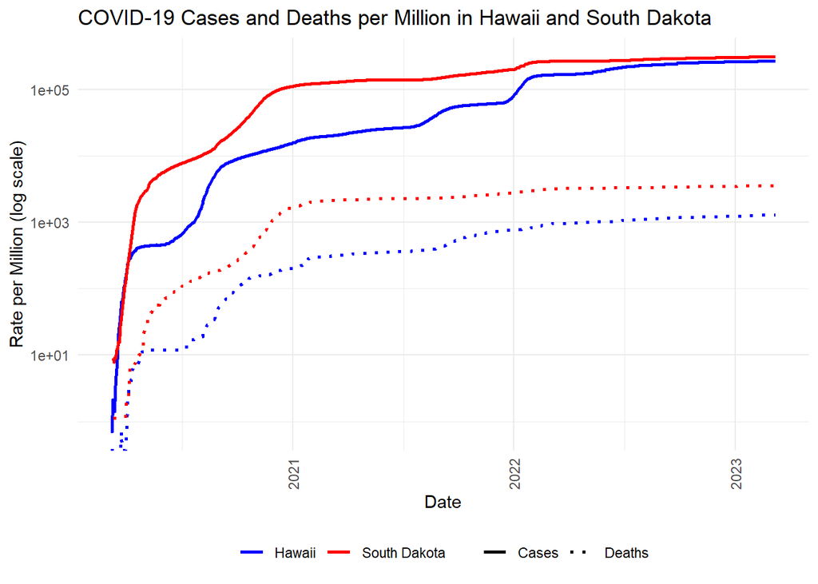

```r
US_by_state %>%
  filter(Province_State %in% c("Hawaii", "South Dakota")) %>%
  filter(cases > 0) %>%
  ggplot(aes(x = date)) +
  geom_line(
    data = . %>% filter(Province_State == "Hawaii"),
    aes(y = cases_per_mill, color = "Hawaii", linetype = "Cases"),
    linewidth = 1
  ) +
  geom_line(
    data = . %>% filter(Province_State == "Hawaii"),
    aes(y = deaths_per_mill, color = "Hawaii", linetype = "Deaths"),
    linewidth = 1
  ) +
  geom_line(
    data = . %>% filter(Province_State == "South Dakota"),
    aes(y = cases_per_mill, color = "South Dakota", linetype = "Cases"),
    linewidth = 1
  ) +
  geom_line(
    data = . %>% filter(Province_State == "South Dakota"),
    aes(y = deaths_per_mill, color = "South Dakota", linetype = "Deaths"),
    linewidth = 1
  ) +
  scale_color_manual(
    values = c("Hawaii" = "blue", "South Dakota" = "red")
  ) +
  scale_linetype_manual(
    values = c("Cases" = "solid", "Deaths" = "dotted")
  ) +
  scale_y_log10() +
  theme_minimal() +
  theme(
    legend.position = "bottom",
    axis.text.x = element_text(angle = 90, vjust = 0.5, hjust = 1),
    legend.title = element_blank()
  ) +
  # Add labels and title
  labs(
    title = "COVID-19 Cases and Deaths per Million in Hawaii and South Dakota",
    x = "Date",
    y = "Rate per Million (log scale)"
  )
```

**These visualizations are interesting. In both examples, the more lenient entities started with a lot more cases, but over time, the more strict ones caught up. However for deaths, the strict entities, never caught up.**